# Week08_Wednesday slides

## Week 08 Wednesday

Wednesday, Oct 16, 2024

**Announcements**

- A07 assigned
- A04 returned
- A06 feedback coming soon (see below)
- Lit review draft due **TONIGHT**

**Goals**

- Need to have a chat about A04/A06
  - These assignments are **most of your grade** (see syllabus) since we have no exams.
  - More than the occasional missing or "punted" assignment
    - A04 explicitly asked for links to code (not google docs with pasted code) and video. Many completely missed this
    - Some didn't follow 4 block structure at all
    - Of those who completed A06, many provided relatively incomplete work
  - Low traffic in office hours slots
  - Low slack traffic asking for help
  - What do we need to do to make sure you're all successful?
- Differential Kinematics

.

.

.

## Differential Kinematics

*Differential Kinematics* is the study of robot motion using *velocities.*

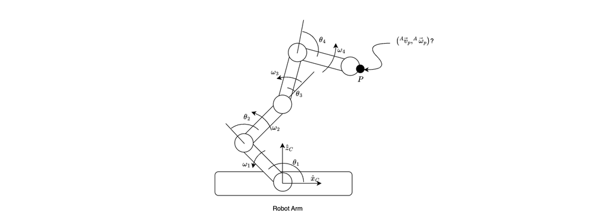

## Why study differential kinematics?

It allows us to study:

- *Non-Holonomic* Robots, or robots whose pose is not uniquely defined by a single set of joint angles. The Romi and other mobile robots are *non-holonomic* because simply specifying their wheel angles does *not* tell you where they are in the world frame! The entire time history of a non-holonomic robot's motion is required to solve for its pose using integration of velocities.
- Forces and torques in robot links and joints! This is because differential kinematics is a *dual problem* to the static analysis of forces and torques, given that the robot's links can be considered *idealized power transducers*.
- velocities of a robot's links rather than positions. This can be useful if an inverse kinematic solution for a robot is not readily available, because it can allow us to drive a robot *towards* a goal location in task space.

## Terminology for differential kinematics

In differential kinematics, we will be studying linear and angular velocities. If a robot end effector's velocity is given by:

\begin{equation} \vec{v}_p = \begin{bmatrix}v_x & v_y & v_z \end{bmatrix}^T \end{equation}

And its angular velocity is given by:

\begin{equation} \vec{\omega}_p = \begin{bmatrix}\omega_x & \omega_y & \omega_z \end{bmatrix}^T \end{equation}

We can define a "generalized velocity" for the robot in task space, called a **twist**, as:

\begin{equation} \vec{\mathcal{V}}_p = \begin{bmatrix}v_x & v_y & v_z & \omega_x & \omega_y & \omega_z \end{bmatrix}^T \end{equation}

## Forward Differential Kinematics

The problem of forward differential kinematics, or the mapping from a twist in configuration space to a twist in task space, is summarized in Equation 4 below.

\begin{equation} \vec{\mathcal{V}}_p = J(\vec{q})\dot{\vec{q}} \end{equation}

\begin{equation} \underbrace{\begin{bmatrix}v_x \\ v_y \\ v_z \\ \omega_x \\ \omega_y \\ \omega_z \end{bmatrix}}_{\vec{\mathcal{V}}} = \underbrace{\begin{bmatrix} \frac{\partial x}{\partial q_1} & \frac{\partial x}{\partial q_2} & \cdots & \frac{\partial x}{\partial q_n} \\ \frac{\partial y}{\partial q_1} & \frac{\partial y}{\partial q_2} & \cdots & \frac{\partial y}{\partial q_n} \\ \frac{\partial z}{\partial q_1} & \frac{\partial z}{\partial q_2} & \cdots & \frac{\partial z}{\partial q_n} \\ \frac{\partial \phi}{\partial q_1} & \frac{\partial \phi}{\partial q_2} & \cdots & \frac{\partial \phi}{\partial q_n} \\ \frac{\partial \theta}{\partial q_1} & \frac{\partial \theta}{\partial q_2} & \cdots & \frac{\partial \theta}{\partial q_n} \\ \frac{\partial \psi}{\partial q_1} & \frac{\partial \psi}{\partial q_2} & \cdots & \frac{\partial \psi}{\partial q_n} \\ \end{bmatrix}}_{J(\vec{q})} \underbrace{\begin{bmatrix} \dot{q}_1 \\ \dot{q}_2 \\ \vdots \\ \dot{q}_n \end{bmatrix}}_{\dot{\vec{q}}} \end{equation}

### Example: Forward Differential Kinematics for a Two-Link Robot

Looking at our forward kinematic equations for the Artybot, we saw:

[figure not shown]

\begin{equation} ^Ax_P = l_2\cos\theta_2+ l_3\left(\cos\theta_2\cos\theta_3 - \sin\theta_2\sin\theta_3\right) \end{equation} \begin{equation} ^Ay_P = l_2\sin\theta_2 + l_3\left(\sin\theta_2\cos\theta_3 + \cos\theta_2\sin\theta_3\right) \end{equation}

## ArtyBot forward differential kinematics

Computing the Jacobian matrix for forward differential kinematics requires taking the following partial derivatives:

\begin{equation} \begin{aligned} \frac{\partial ^Ax_p}{\partial \theta_2} &= - l_2\sin\theta_2 + l_3\left(-\sin\theta_2\cos\theta_3 - \cos\theta_2\sin\theta_3\right) \\ \frac{\partial ^Ay_p}{\partial \theta_2} &= l_2\cos\theta_2 + l_3\left(\cos\theta_2\cos\theta_3 - \sin\theta_2\sin\theta_3\right) \\ \frac{\partial ^Ax_p}{\partial \theta_3} &= -l_3\left(\cos\theta_2\sin\theta_3 + \sin\theta_2\cos\theta_3\right) \\ \frac{\partial ^Ay_p}{\partial \theta_3} &= l_3\left(-\sin\theta_2\sin\theta_3 + \cos\theta_2\cos\theta_3\right) \end{aligned} \end{equation}

Then, the forward differential kinematic equation for the Artybot can be written:

\begin{equation} \begin{bmatrix} ^A\dot{x}_p \\ ^A\dot{y}_p \end{bmatrix} = \begin{bmatrix} \frac{\partial ^Ax_p}{\partial \theta_2} & \frac{\partial ^Ax_p}{\partial \theta_3} \\ \frac{\partial ^Ay_p}{\partial \theta_2} & \frac{\partial ^Ay_p}{\partial \theta_3} \end{bmatrix} \begin{bmatrix} \dot{\theta}_2 \\ \dot{\theta_3}\end{bmatrix} \end{equation}

.

.

.

### Example: Romi Forward Differential Kinematics

We have actually done differential kinematics for the Romi before when we studied Odometry!! As a reminder, The problem setup looked something like this:

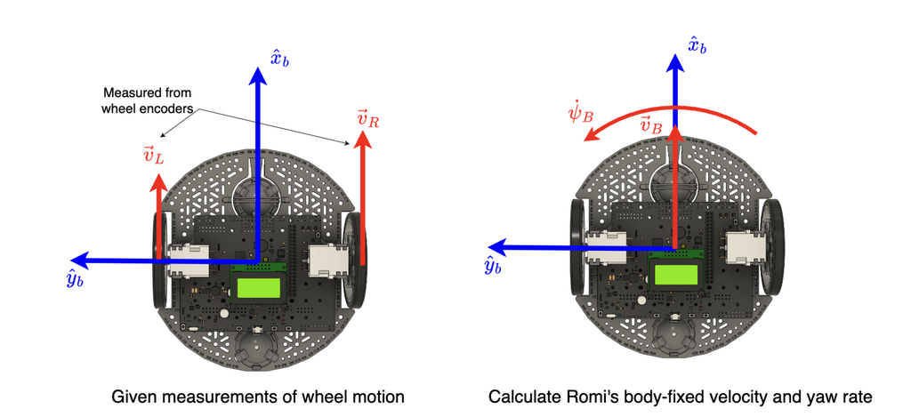

## Romi Forward Differential Kinematics

What we found was that:

\begin{equation} \dot{\psi} = \frac{v_R-v_L}{2r} \end{equation}

and

\begin{equation} v_b = \frac{v_L+v_R}{2} \end{equation}

## Inverse Differential Kinematics

If the robot's Jacobian is invertible, the inverse differential kinematic equation, which maps generalized velocities in *task space* to generalized *joint velocities*, is given by:

\begin{equation} \dot{\vec{q}} = J(\vec{q})^{-1}\vec{\mathcal{V}} \end{equation}

For J to be invertible, its determinant cannot be zero, and it must be square. Often, however, J is *not* square, because the dimensionality of the task and configuration spaces for the robot are not the same. In those cases, we can use the *pseudoinverse* of J:

\begin{equation} J^+ = J^T\left(JJ^T\right)^{-1} \end{equation}

## Using inverse differential kinematics to reach a goal in task space

If the subscript "d" indicates a static "goal" value, and we define "eror" for the robot's end effector in task space as:

\begin{equation} \vec{e} = \begin{bmatrix} x_d-x & y_d - y& \cdots & \omega_{nd} - \omega_n \end{bmatrix}^T \end{equation}

Then we can progressively drive a robot's end effector towards the goal using the pseudoinverse of its Jacobian matrix:

\begin{equation} \vec{q} = J^+ e \end{equation}

As error gets smaller, the robot will move more and more slowly and (hopefully) approach the goal.

## Exercise: Make Romi move with a specified forward velocity and yaw rate.

If we wanted Romi to move in a circle of radius $R$ at some foward speed $U$, we could compute a goal yaw rate for the robot as:

\begin{equation} \psi_g = \frac{U}{R} \end{equation}

This means that we could specify a "goal" for the Romi's body-fixed task space as:

\begin{equation} \vec{q}_g = \begin{bmatrix}^B\dot{x}_g & ^B\dot{y}_g & ^B\dot{\psi}_g\end{bmatrix}=\begin{bmatrix}U & 0 & \frac{U}{R}\end{bmatrix} \end{equation}

## Exercise: Make Romi move with a specified forward velocity and yaw rate.

In the Week09_World in Webots, implement inverse differential kinematics as shown above to achieve any given yaw rate and any given forward speed. There is a "Starter Controller" in that world for your use. You will need to:

- Calculate wheel speeds
- compute yaw rate
- compute forward Romi speed
- Compute the Jacobian
- Compute the pseudoinverse of the Jacobian
- Compute wheel speeds needed to achieve the desired yaw rate and forward velocity, ultimately achieving your goal turn radius $R$.

Finally, use the supervisor to compare Romi's actual motion with your goal for its motion.